# Data science in R presentation_Xianyuan

## Import data

I first loaded single cell sequencing data from github, which was created by a former Tidybiology TA.

```r
#devtools::install_github("devangthakkar/scRNAseq", force = TRUE)
library(scRNAseq)
```

## Take a glimpse of the data

Next, I found that this table has 23 variables and 54,703 observations.

```r
scRNAseq %>%
  group_by(organ) %>%
  summarise(across(contains("cell"), mean))
```

```
## # A tibble: 4 × 11
##   organ  cell_1 cell_2 cell_3 cell_4 cell_5 cell_6 cell_7 cell_8 cell_9 cell_10
##   <chr>   <dbl>  <dbl>  <dbl>  <dbl>  <dbl>  <dbl>  <dbl>  <dbl>  <dbl>   <dbl>
## 1 brain    19.9   19.0  101.    19.0   99.7   19.9   18.5   18.9   20.0   100.
## 2 heart   103.    19.9   18.8   97.0   19.9   19.4   20.5   20.6  106.     19.2
## 3 kidney   20.0  101.    20.4   19.6   19.4  100.   103.    98.6   19.6    19.2
## 4 other    19.5   19.5   19.5   19.5   19.5   19.5   19.5   19.5   19.5    19.5
```

## EDA

I then did exploratory data analysis with this single cell RNA seq data. First I looked at the abundance of RNA of different transcript length that is specifically expressed in distinct organs from all 10 cells. The transcript length of RNAs that are specifically expressed in brain, heart and kidney is mostly below 20,000 and their quantity is mostly between 50 to 150, whereas the others have more longer transcripts at low quantity.

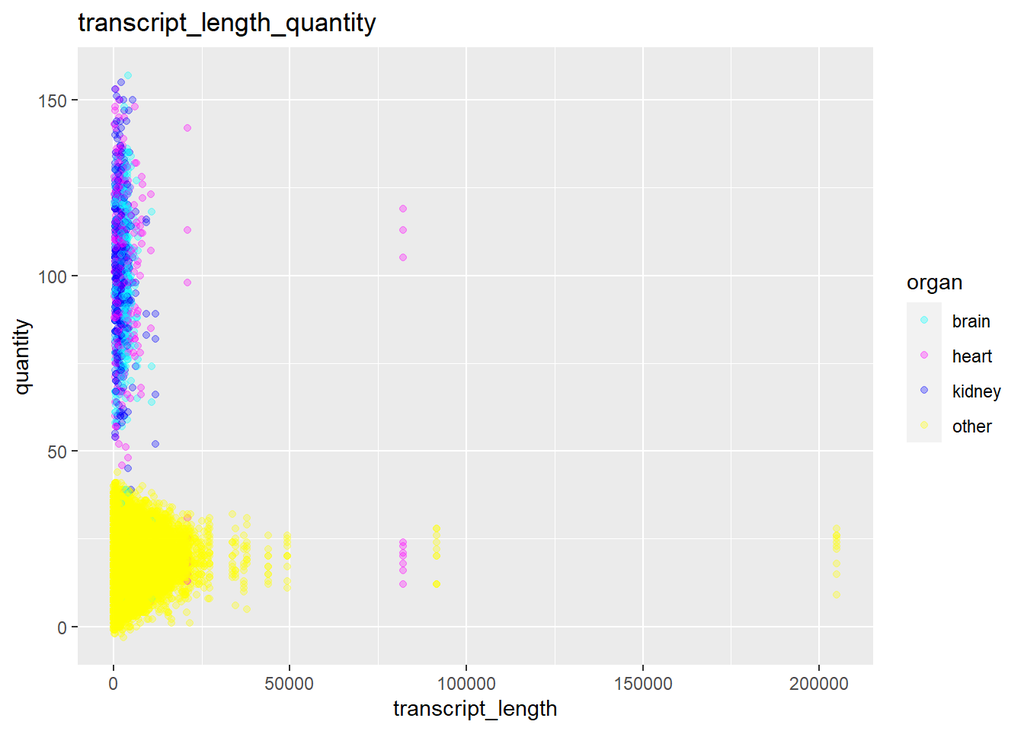

```r
data("scRNAseq")
pivot_scRNAseq <-
  scRNAseq %>%
  pivot_longer(cols = 14:23, names_to ="cell",
               values_to = "quantity")
pivot_scRNAseq %>%
  ggplot(aes(transcript_length, quantity,color=organ) )+
  geom_point(alpha=0.3)+
  scale_color_manual(values = c("brain" = "cyan",
                                "heart"="magenta",
                                "kidney"="blue",
                                "other"="yellow"))+
  labs(title="transcript_length_quantity")
```

Next I removed the genes that are expressed in other organs and only look at the abundance of RNA of different transcript length from brain, heart and kidney. The points are colored by their gene type.

In this RNAseq data set, it is shown that brain, heart and kidney-specific genes only have protein_coding and lncRNA genes.

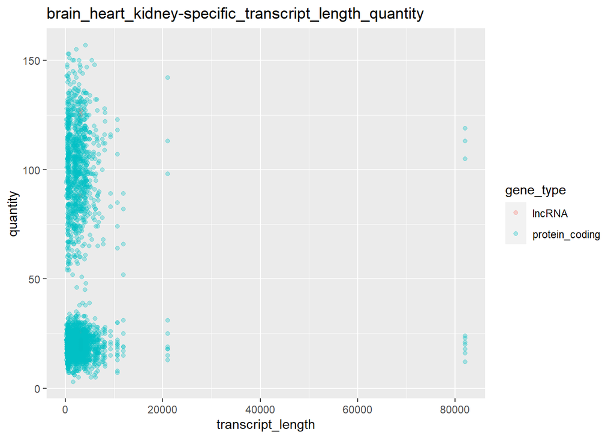

```r
pivot_scRNAseq %>%
  filter(organ!="other")%>%
  ggplot(aes(transcript_length, quantity, color=gene_type) )+
  geom_point(alpha=0.3)+
   labs(title="brain_heart_kidney-specific_transcript_length_quantity")
```

However, genes that are expressed in other organs showed a bigger variety of gene types.

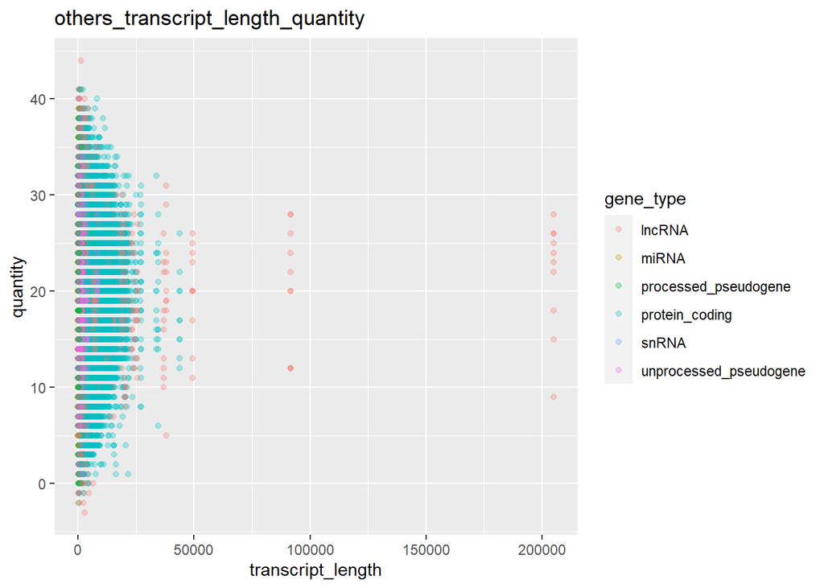

```r
pivot_scRNAseq %>%
  filter(organ=="other")%>%
  ggplot(aes(transcript_length, quantity, color=gene_type) )+
  geom_point(alpha=0.3)+
  labs(title="others_transcript_length_quantity")
```

To investigate the transcripts that specifically abaundant in brain cells, I reshaped my data and looked at the log2 fold change in the expression level between the pooled data of brain cells relative to other type of cells.

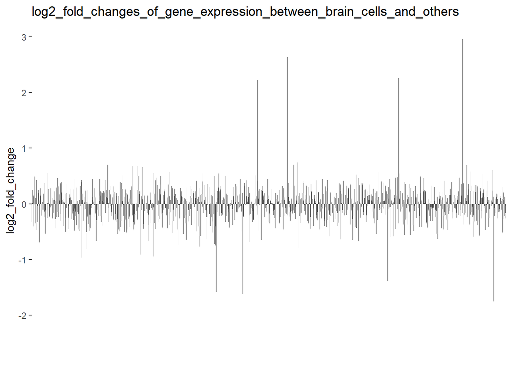

```r
brain_cell_RNAseq <-
  pivot_scRNAseq %>%
  filter(cell=="cell_3"|cell=="cell_5"|cell=="cell_10")
brain_mean_quantity <-
  brain_cell_RNAseq%>%
  group_by(gene_name) %>%
  summarise(mean(quantity))%>%
  janitor::clean_names()

other_cell_RNAseq <-
  pivot_scRNAseq %>%
  filter(cell!="cell_3"&cell!="cell_5"&cell!="cell_10")
other_mean_quantity<-
  other_cell_RNAseq%>%
  group_by(gene_name) %>%
  summarise(mean(quantity))%>%
  janitor::clean_names()


fold_change_value <-
  brain_mean_quantity$mean_quantity/other_mean_quantity$mean_quantity
fold_change=tibble(brain_mean_quantity$gene_name,fold_change_value)
fold_change$log2_fold_change=log2(fold_change$fold_change_value)
colnames(fold_change)[1] = "gene_name"

fold_change %>%
  ggplot()+
  geom_col(aes(gene_name, log2_fold_change))+
  labs(title="log2_fold_changes_of_gene_expression_between_brain_cells_and_others")+
   theme(axis.title.x=element_blank(),
        axis.text.x=element_blank(),
        axis.ticks.x=element_blank())
```

##Final graph

For the final graph, I plotted the -log10 of P-values for comparing the quantity of transcripts between the pooled data of brain cells relative to all other cell types against the log2 of fold changes in the expression levels.

```r
brain_cell_seq2 <-
  scRNAseq %>%
  select (gene_name, cell_3, cell_5, cell_10)

other_cell_seq2 <-
  scRNAseq %>%
  select (gene_name, cell_1, cell_2, cell_4,cell_6, cell_7, cell_8,cell_9)

testresults <- vector("list", nrow(brain_cell_seq2))
pvalues <- vector("numeric", nrow(brain_cell_seq2))
#For loop
for (j in seq(nrow(brain_cell_seq2))){
  testresults[[j]]<- t.test(brain_cell_seq2[, c(2:4)][j,], other_cell_seq2[, c(2:8)][j,])
  pvalues[[j]]<-testresults[[j]]$p.value
}
```

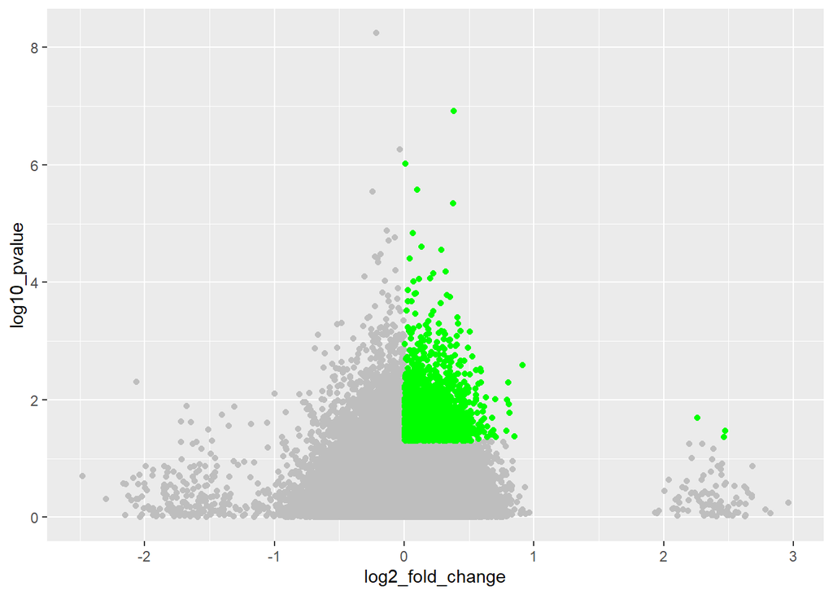

```r
ggplot()+
   geom_point(data = fold_change,
              aes(log2_fold_change, log10_pvalue),
              color="gray") +
  geom_point(data=fold_change %>% filter(log2_fold_change>0 & log10_pvalue>-log10(0.05)), aes(x=log2_fold_change, y=log10_pvalue), color="green")
```

```r
interested_genes<-
fold_change %>%
  filter(log2_fold_change>0 & log10_pvalue>-log10(0.05))
```

##Conclusion

In this scRNAseq data, the transcript length of RNAs that are specifically expressed in brain, heart and kidney is mostly below 20,000 and their quantity is mostly between 50 to 150, whereas the others have more longer transcripts at low quantity. Besides,brain, heart and kidney-specific genes only have protein_coding and lncRNA genes.

##Prioritized follow-up studies

It might be interesting to look at the functions of those enriched transcripts in these brain cells in relation to certain phenotype of interest.

##Acknowledgement

I would like to thank Matthew for the wonderful workshop and everybody in the class!